Wiederaufnahme

# Winterreise

Choreographie und Inszenierung von *Christian Spuck*  
Musik von *Hans Zender*  
«Schuberts ‹Winterreise›. Eine komponierte Interpretation für Tenor und kleines Orchester»

Franz Schuberts *Winterreise*, ein Zyklus aus 24 Liedern für Singstimme und Klavier auf Gedichte von Wilhelm Müller, ist im Herbst 1827, ein Jahr vor Schuberts Tod, entstanden. Der Zyklus gilt nicht nur als Höhepunkt in Schuberts Liedschaffen, sondern als Gipfel des deutschen Kunstlieds überhaupt. In 24 Momentaufnahmen fächert Schubert kaleidoskopartig die Stimmungslage eines verlorenen, verletzten und vereinsamten Charakters auf. Nur wenige Kunstwerke haben das Existentielle, das Zerrissene des Menschseins so erschütternd zum Ausdruck gebracht.

Der deutsche Komponist Hans Zender bearbeitete den Zyklus unter dem Titel: *Schuberts «Winterreise». Eine komponierte Interpretation*. Zenders Fassung für Tenor und kleines Orchester, die 1993 in Frankfurt uraufgeführt wurde, ist weit mehr als eine einfache Orchestrierung. Ebenso einfühlsam wie radikal legt sie das Verstörungspotential des Zyklus frei und nähert sich den Gedichten Wilhelm Müllers noch einmal auf eigene Weise. Zender stößt in die dunkelsten Regionen des Menschseins vor. Mit seiner Interpretation fördert er Emotionen zu Tage, die bei Schubert unter der Oberfläche pulsieren und deckt die unheimlichen Schichten in der Tiefe der Musik auf.

Ähnlich wie Hans Zender geht es Christian Spuck in seiner Inszenierung weniger darum, die äußerlichen Stationen des Reisenden zu bebildern, als sich vielmehr in ausgreifender Abstraktion mit dem Zyklus auseinanderzusetzen. In einer Mischung aus großen Ensembleszenen und einer Vielzahl intimer Solobilder unternimmt er eine Reise ins Innere des Menschen. Dabei erkundet er so zeitlose Themen wie Liebe, Sehnsucht, Entfremdung und Verlassenheit und ermöglicht mit den Mitteln des Tanzes eine neue Perspektive auf eines der großen Meisterwerke klassischer Musik.

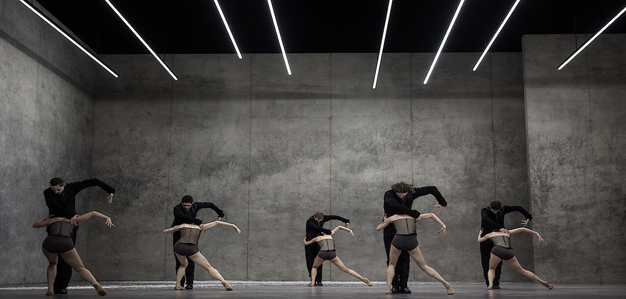

Termine

2026

Fr.27.2.2026Ausverkauft

So.1.3.2026(NV)Restkarten

So.1.3.2026(AV)Restkarten

Mi.4.3.2026Restkarten

Info

Staatsoper Unter den Linden

19.30 Uhr

1 h 35 min ohne Pause

[Termin speichern](https://www.staatsballett-berlin.de/system/sites/ical/content/event/715.html)

Einführung zum Stück jeweils 45 Minuten vor der Veranstaltung

### Besetzung27.2.

Choreographie und Inszenierung [Christian Spuck](https://www.staatsballett-berlin.de/kompanie/personen-detail/peid/christian-spuck/1000451.html)  
Musik [Hans Zender](https://www.staatsballett-berlin.de/kompanie/personen-detail/peid/hans-zender/2001089.html)  
Bühnenbild [Rufus Didwiszus](https://www.staatsballett-berlin.de/kompanie/personen-detail/peid/rufus-didwiszus/2000925.html)  
Kostüme [Emma Ryott](https://www.staatsballett-berlin.de/kompanie/personen-detail/peid/emma-ryott/2000924.html)  
Licht [Martin Gebhardt](https://www.staatsballett-berlin.de/kompanie/personen-detail/peid/martin-gebhardt/2000926.html)  
Dramaturgie [Christian Spuck](https://www.staatsballett-berlin.de/kompanie/personen-detail/peid/christian-spuck/1000451.html) / [Michael Küster](https://www.staatsballett-berlin.de/kompanie/personen-detail/peid/michael-kuster/2000953.html) / [Katja Wiegand](https://www.staatsballett-berlin.de/kompanie/personen-detail/peid/katja-wiegand/2000564.html)  
Einstudierung [Daniel Mulligan](https://www.staatsballett-berlin.de/kompanie/personen-detail/peid/daniel-mulligan/2001236.html) / [Eva Dewaele](https://www.staatsballett-berlin.de/kompanie/personen-detail/peid/eva-dewaele/2000541.html) / [Fabio Palombo](https://www.staatsballett-berlin.de/kompanie/personen-detail/peid/fabio-palombo/2001035.html)  
Musikalische Leitung [Benjamin Schneider](https://www.staatsballett-berlin.de/kompanie/personen-detail/peid/benjamin-schneider/2001091.html)  
Staatskapelle Berlin  
Tenor [Matthew Newlin](https://www.staatsballett-berlin.de/kompanie/personen-detail/peid/matthew-newlin/2001093.html)

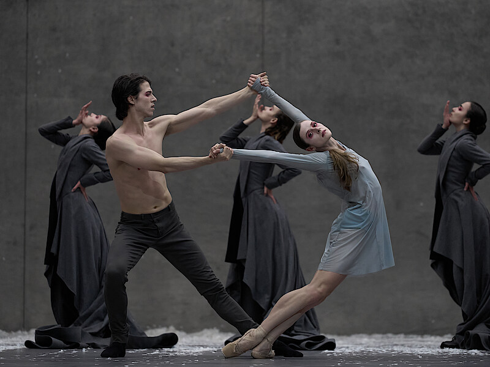

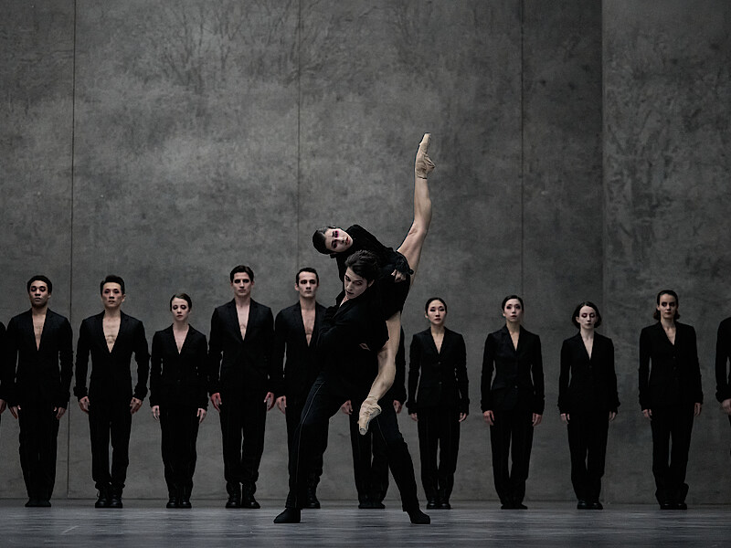

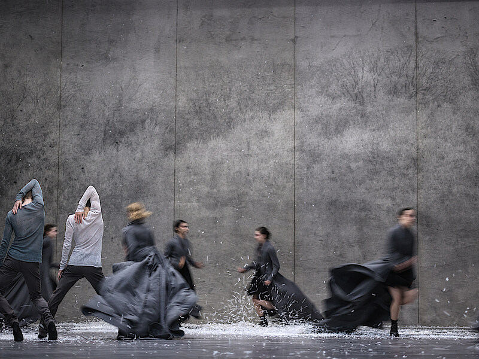

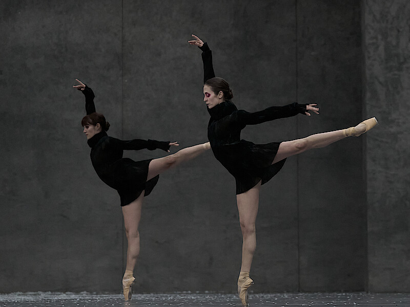

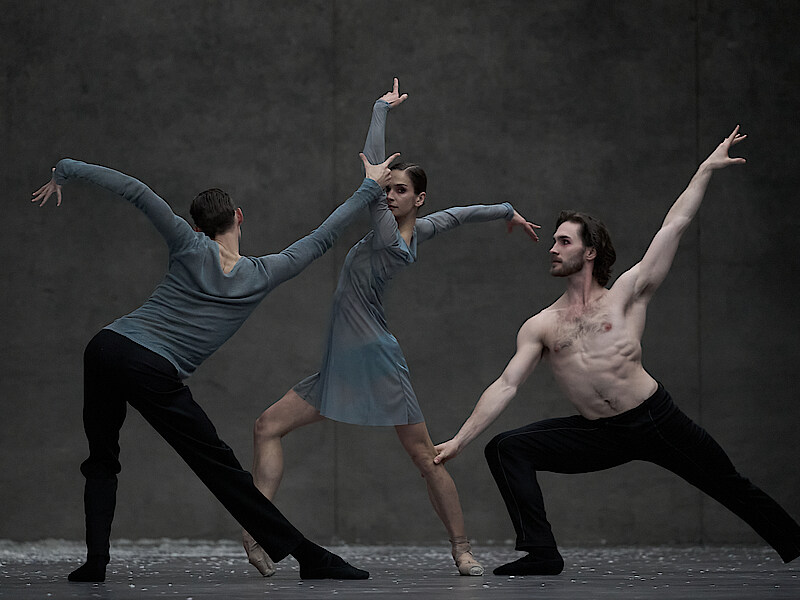

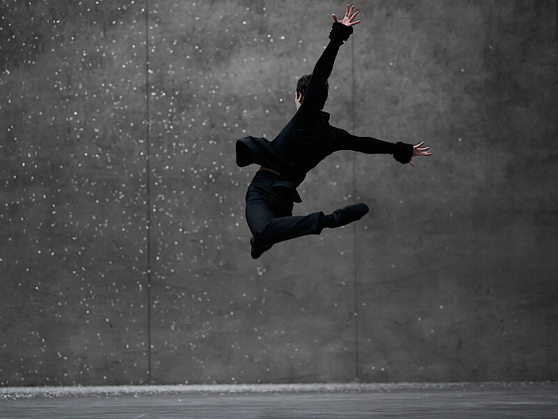

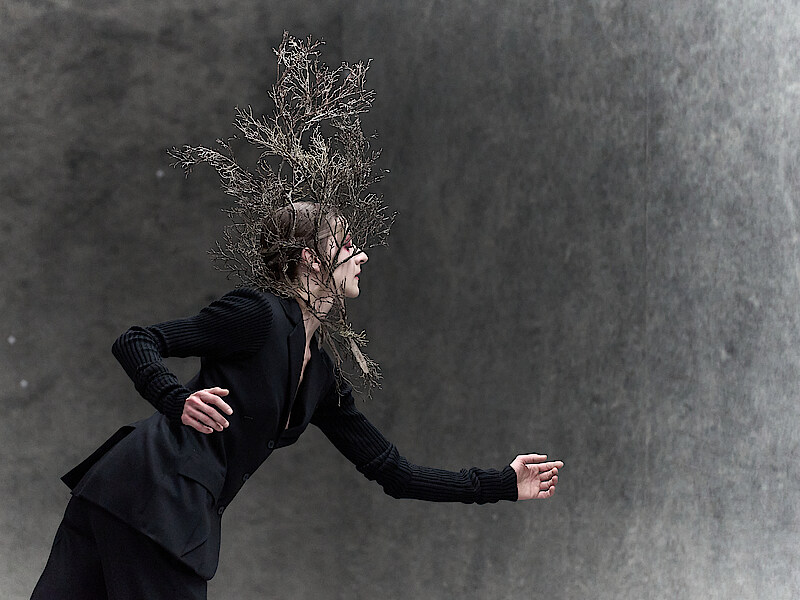

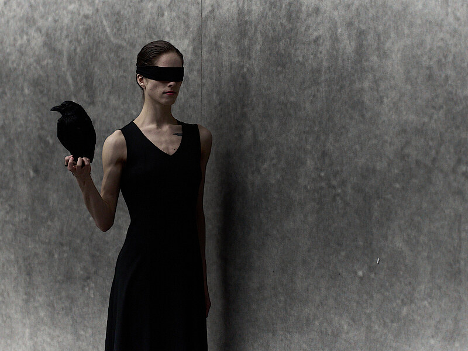

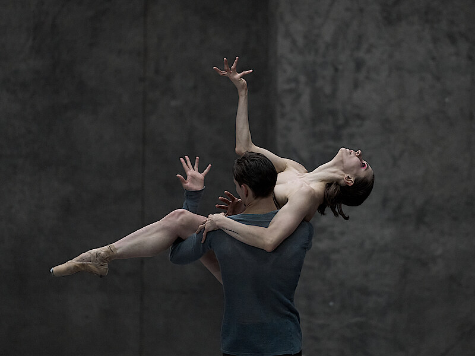

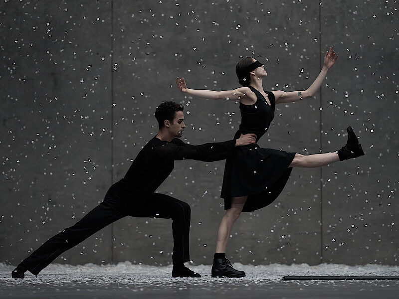

> «Der Tanz wird hier vollends zur Seelenlandschaft, sprengt die eisige Szenerie. Das Ganze ist von einer apokalyptischen Schönheit, die tief berührt.»

##### NZZ

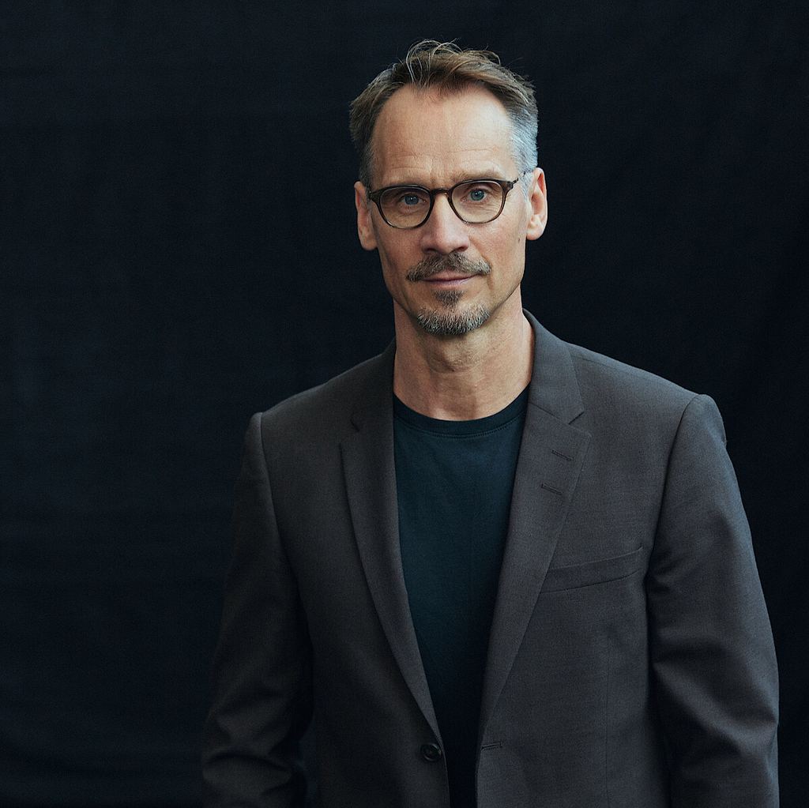

### «Je verrätselter die Bilder, desto klarer die Botschaft»

Christian Spuck im Interview

Franz Schuberts *Winterreise* gehört zu den Meisterwerken der Musikgeschichte. Intendant und Choreograph Christian Spuck hat sich von Hans Zenders außergewöhnlicher Bearbeitung inspirieren lassen und eine ganz eigene Sicht auf den Zyklus bestehend aus 24 Liedern geschaffen. Im Interview spricht Spuck über seine Faszination mit Zenders Interpretation der *Winterreise*, wie man Kälte und Einsamkeit auf der Bühne zum Ausdruck bringt, und warum dieses Werk auch heute seine Aktualität nicht verloren hat.

*Staatsballett Berlin:* Kannst du dich erinnern, wann du zum ersten Mal Schuberts *Winterreise* gehört hast?

*Christian Spuck:* Ich habe die *Winterreise* das erste Mal als junger Mensch gehört. Manche Lieder bringen eine Emotionalität mit, die mich damals angesprochen hat. Das waren ganz eindeutig die Melancholie, der Umgang mit Einsamkeit, die Begegnung mit dem «Ich». In einer kalten Welt verlassen worden zu sein, aufzubrechen, nicht anzukommen, sich selbst zu finden.

[mehr lesen](https://www.staatsballett-berlin.de/spielplan/stueck-detail.html#read-more-1770108366-23-0)

Empfehlungen

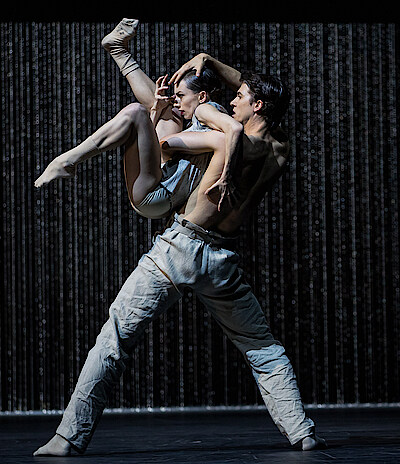

### Gods and Dogs

Choreographien von *Jiří Kylián* und *Crystal Pite*

Staatsoper Unter den Linden

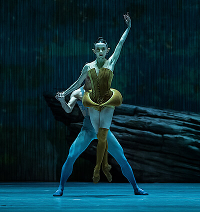

### Ein Sommernachtstraum

Ballett von *Edward Clug* nach *William Shakespeare*  
Musik von *Milko Lazar* (Auftragswerk)

Deutsche Oper Berlin

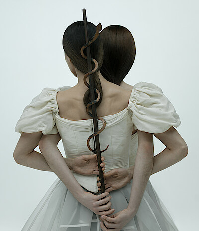

### Fearful Symmetries

Choreographien von *George Balanchine* und *Christian Spuck*

Staatsoper Unter den Linden